# 01_03_pandas_02

## 05 판다스를 활용한 데이터 이해

### 학습 내용

- 캘리포니아 데이터 살펴보기
- 원하는 데이터를 선택하는 것을 실습을 통해 알아본다.

### 01 캘리포니아 데이터 확인해 보기

```python
import pandas as pd
```

```python
print("pandas 버전 ", pd.__version__)
```

```
pandas 버전  1.1.3
```

```python
test = pd.read_csv("../data/california/california_housing_test.csv")
train = pd.read_csv("../data/california/california_housing_train.csv")
```

```python
### 데이터 확인
print("test 데이터 셋 행열 크기 :", test.shape)
print("train 데이터 셋 행열 크기 : ", train.shape)
```

```
test 데이터 셋 행열 크기 : (3000, 9)
train 데이터 셋 행열 크기 :  (17000, 9)
```

```python
### 데이터 5행 확인
test.head()
```

|  | longitude | latitude | housing_median_age | total_rooms | total_bedrooms | population | households | median_income | median_house_value |
| --- | --- | --- | --- | --- | --- | --- | --- | --- | --- |
| 0 | -122.05 | 37.37 | 27.0 | 3885.0 | 661.0 | 1537.0 | 606.0 | 6.6085 | 344700.0 |
| 1 | -118.30 | 34.26 | 43.0 | 1510.0 | 310.0 | 809.0 | 277.0 | 3.5990 | 176500.0 |
| 2 | -117.81 | 33.78 | 27.0 | 3589.0 | 507.0 | 1484.0 | 495.0 | 5.7934 | 270500.0 |
| 3 | -118.36 | 33.82 | 28.0 | 67.0 | 15.0 | 49.0 | 11.0 | 6.1359 | 330000.0 |
| 4 | -119.67 | 36.33 | 19.0 | 1241.0 | 244.0 | 850.0 | 237.0 | 2.9375 | 81700.0 |

```python
### 데이터 5행 확인
train.head()
```

|  | longitude | latitude | housing_median_age | total_rooms | total_bedrooms | population | households | median_income | median_house_value |
| --- | --- | --- | --- | --- | --- | --- | --- | --- | --- |
| 0 | -114.31 | 34.19 | 15.0 | 5612.0 | 1283.0 | 1015.0 | 472.0 | 1.4936 | 66900.0 |
| 1 | -114.47 | 34.40 | 19.0 | 7650.0 | 1901.0 | 1129.0 | 463.0 | 1.8200 | 80100.0 |
| 2 | -114.56 | 33.69 | 17.0 | 720.0 | 174.0 | 333.0 | 117.0 | 1.6509 | 85700.0 |
| 3 | -114.57 | 33.64 | 14.0 | 1501.0 | 337.0 | 515.0 | 226.0 | 3.1917 | 73400.0 |
| 4 | -114.57 | 33.57 | 20.0 | 1454.0 | 326.0 | 624.0 | 262.0 | 1.9250 | 65500.0 |

```python
### 어떤 컬럼명을 가지고 있을까?
print(test.columns)
print(train.columns)
```

```
Index(['longitude', 'latitude', 'housing_median_age', 'total_rooms',
       'total_bedrooms', 'population', 'households', 'median_income',
       'median_house_value'],
      dtype='object')
Index(['longitude', 'latitude', 'housing_median_age', 'total_rooms',
       'total_bedrooms', 'population', 'households', 'median_income',
       'median_house_value'],
      dtype='object')
```

```python
### 데이터는 어떤 자료형을 갖는가?
print(test.dtypes)
print()
print(train.dtypes)
```

```
longitude             float64
latitude              float64
housing_median_age    float64
total_rooms           float64
total_bedrooms        float64
population            float64
households            float64
median_income         float64
median_house_value    float64
dtype: object

longitude             float64
latitude              float64
housing_median_age    float64
total_rooms           float64
total_bedrooms        float64
population            float64
households            float64
median_income         float64
median_house_value    float64
dtype: object
```

```python
### 데이터는 어떤 자료형을 갖는가?
print(test.info())
```

```
<class 'pandas.core.frame.DataFrame'>
RangeIndex: 3000 entries, 0 to 2999
Data columns (total 9 columns):
 #   Column              Non-Null Count  Dtype
---  ------              --------------  -----
 0   longitude           3000 non-null   float64
 1   latitude            3000 non-null   float64
 2   housing_median_age  3000 non-null   float64
 3   total_rooms         3000 non-null   float64
 4   total_bedrooms      3000 non-null   float64
 5   population          3000 non-null   float64
 6   households          3000 non-null   float64
 7   median_income       3000 non-null   float64
 8   median_house_value  3000 non-null   float64
dtypes: float64(9)
memory usage: 211.1 KB
None
```

```python
print(train.info())
```

```
<class 'pandas.core.frame.DataFrame'>
RangeIndex: 17000 entries, 0 to 16999
Data columns (total 9 columns):
 #   Column              Non-Null Count  Dtype
---  ------              --------------  -----
 0   longitude           17000 non-null  float64
 1   latitude            17000 non-null  float64
 2   housing_median_age  17000 non-null  float64
 3   total_rooms         17000 non-null  float64
 4   total_bedrooms      17000 non-null  float64
 5   population          17000 non-null  float64
 6   households          17000 non-null  float64
 7   median_income       17000 non-null  float64
 8   median_house_value  17000 non-null  float64
dtypes: float64(9)
memory usage: 1.2 MB
None
```

```python
### 데이터는 어떤 값들을 갖는가?
train.describe()
```

|  | longitude | latitude | housing_median_age | total_rooms | total_bedrooms | population | households | median_income | median_house_value |
| --- | --- | --- | --- | --- | --- | --- | --- | --- | --- |
| count | 17000.000000 | 17000.000000 | 17000.000000 | 17000.000000 | 17000.000000 | 17000.000000 | 17000.000000 | 17000.000000 | 17000.000000 |
| mean | -119.562108 | 35.625225 | 28.589353 | 2643.664412 | 539.410824 | 1429.573941 | 501.221941 | 3.883578 | 207300.912353 |
| std | 2.005166 | 2.137340 | 12.586937 | 2179.947071 | 421.499452 | 1147.852959 | 384.520841 | 1.908157 | 115983.764387 |
| min | -124.350000 | 32.540000 | 1.000000 | 2.000000 | 1.000000 | 3.000000 | 1.000000 | 0.499900 | 14999.000000 |
| 25% | -121.790000 | 33.930000 | 18.000000 | 1462.000000 | 297.000000 | 790.000000 | 282.000000 | 2.566375 | 119400.000000 |
| 50% | -118.490000 | 34.250000 | 29.000000 | 2127.000000 | 434.000000 | 1167.000000 | 409.000000 | 3.544600 | 180400.000000 |
| 75% | -118.000000 | 37.720000 | 37.000000 | 3151.250000 | 648.250000 | 1721.000000 | 605.250000 | 4.767000 | 265000.000000 |
| max | -114.310000 | 41.950000 | 52.000000 | 37937.000000 | 6445.000000 | 35682.000000 | 6082.000000 | 15.000100 | 500001.000000 |

- 1. longitude: A measure of how far west a house is; a higher value is farther west
- 1. latitude: A measure of how far north a house is; a higher value is farther north
- 1. housingMedianAge: Median age of a house within a block; a lower number is a newer building
- 1. totalRooms: Total number of rooms within a block
- 1. totalBedrooms: Total number of bedrooms within a block
- 1. population: Total number of people residing within a block
- 1. households: Total number of households, a group of people residing within a home unit, for a block
- 1. medianIncome: Median income for households within a block of houses (measured in tens of thousands of US Dollars)
- 1. medianHouseValue: Median house value for households within a block (measured in US Dollars)

### 데이터 셋 설명

- longitude : 집이 서쪽으로 얼마나 떨어져 있는지를 나타내는 척도. 집이 서쪽으로 얼마나 떨어져 있는지를 나타내는 척도. 더 높은 값은 서쪽으로 더 멀리 있다.
- latitude : 주택이 북쪽으로 얼마나 떨어져 있는지를 나타내는 척도. 더 높은 값은 북쪽으로 더 멀리 있음.
- housingMedianAge : 블록내 주택의 중간값 연식. 낮은 숫자는 최신 건물
- totalRooms : 총 객실 수
- totalBedrooms : 블록 내 총 침실 수
- population : 블록 내에 상주하는 총 인원 수
- households : 주택 단위 내에 거주하는 가구 그룹인 블록의 총 가구 수
- medianIncome : 한 블록 내 가구의 중위 소득(미국 달러 수만달러로 추정)
- medianHouseValue : 블록 내 가구의 중위 House Value(미국 달러로 추정)

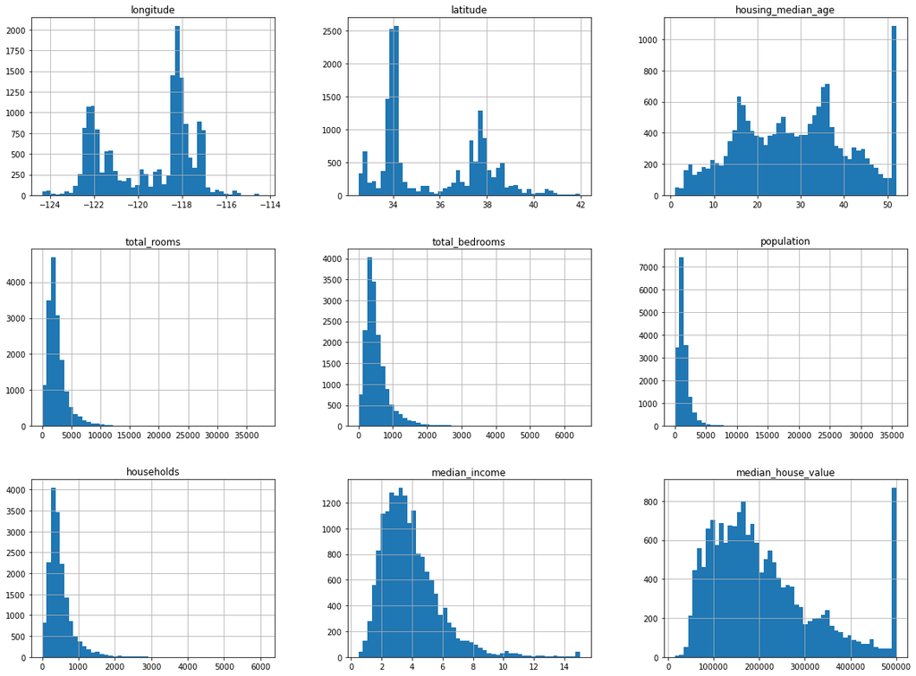

```python
import matplotlib.pyplot as plt
train.hist(bins=50, figsize=(20,15))
plt.show()
```

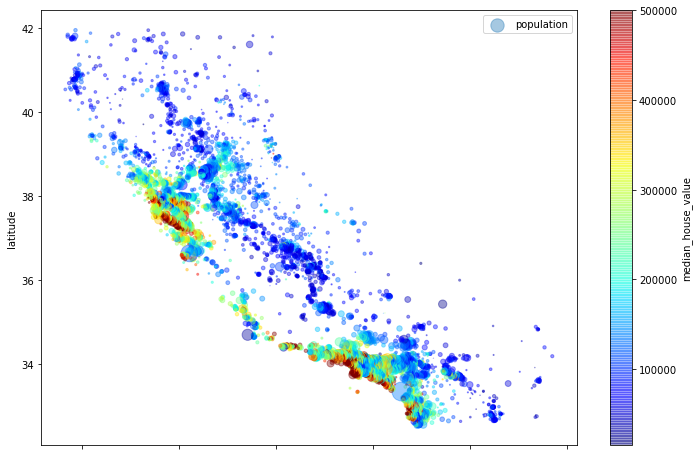

```python
### 위도 경도에 따른 산점도 분포
train.plot(kind="scatter",
           x="longitude", y="latitude",
           alpha=0.4, s=train["population"]/100,
           label="population", c="median_house_value",
           figsize=(12,8),
           cmap=plt.get_cmap("jet"), colorbar=True)
```

```python
train.columns
```

```
Index(['longitude', 'latitude', 'housing_median_age', 'total_rooms',
       'total_bedrooms', 'population', 'households', 'median_income',
       'median_house_value'],
      dtype='object')
```

```python
sel = ['total_rooms', 'total_bedrooms', 'population']

temp_train = train[ sel  ]

print("데이터 가공 셋의 크기 : ", temp_train.shape)
print("데이터 가공 셋의 일부 : ", temp_train.head())
```

```
데이터 가공 셋의 크기 :  (17000, 3)
데이터 가공 셋의 일부 :     total_rooms  total_bedrooms  population
0       5612.0          1283.0      1015.0
1       7650.0          1901.0      1129.0
2        720.0           174.0       333.0
3       1501.0           337.0       515.0
4       1454.0           326.0       624.0
```

```python
temp_train.describe()
```

|  | total_rooms | total_bedrooms | population |
| --- | --- | --- | --- |
| count | 17000.000000 | 17000.000000 | 17000.000000 |
| mean | 2643.664412 | 539.410824 | 1429.573941 |
| std | 2179.947071 | 421.499452 | 1147.852959 |
| min | 2.000000 | 1.000000 | 3.000000 |
| 25% | 1462.000000 | 297.000000 | 790.000000 |
| 50% | 2127.000000 | 434.000000 | 1167.000000 |
| 75% | 3151.250000 | 648.250000 | 1721.000000 |
| max | 37937.000000 | 6445.000000 | 35682.000000 |

```python
import seaborn as sns
```

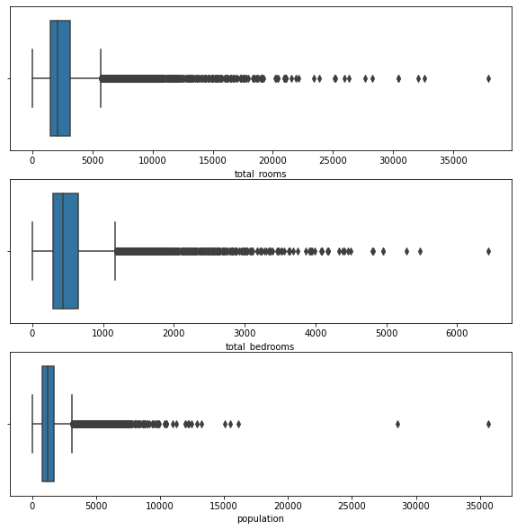

```python
plt.figure(figsize=(10,10))

plt.subplot(3,1,1)
sns.boxplot(x="total_rooms", data=temp_train)
plt.subplot(3,1,2)
sns.boxplot(x="total_bedrooms", data=temp_train)
plt.subplot(3,1,3)
sns.boxplot(x="population", data=temp_train)
```

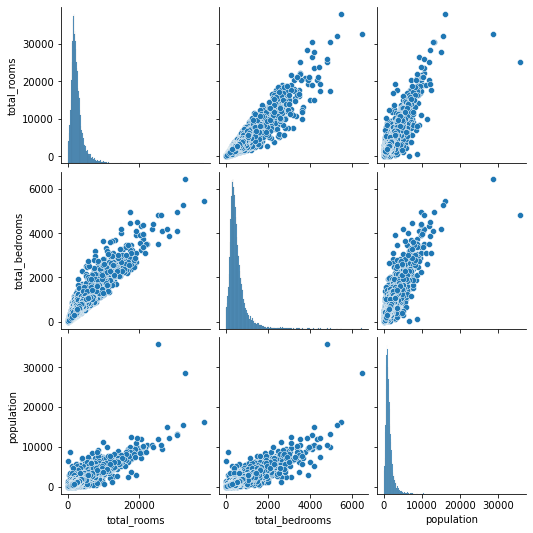

```python
sns.pairplot(temp_train)
```

### iloc, Loc 이해하기

```python
train.columns
```

```
Index(['longitude', 'latitude', 'housing_median_age', 'total_rooms',
       'total_bedrooms', 'population', 'households', 'median_income',
       'median_house_value'],
      dtype='object')
```

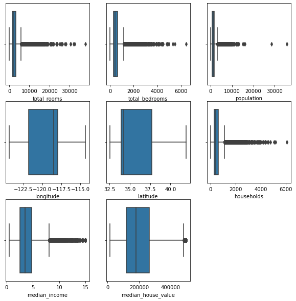

```python
plt.figure(figsize=(10,10))

plt.subplot(3,3,1)
sns.boxplot(x="total_rooms", data=train)
plt.subplot(3,3,2)
sns.boxplot(x="total_bedrooms", data=train)
plt.subplot(3,3,3)
sns.boxplot(x="population", data=train)

plt.subplot(3,3,4)
sns.boxplot(x="longitude", data=train)
plt.subplot(3,3,5)
sns.boxplot(x="latitude", data=train)
plt.subplot(3,3,6)
sns.boxplot(x="households", data=train)

plt.subplot(3,3,7)
sns.boxplot(x="median_income", data=train)
plt.subplot(3,3,8)
sns.boxplot(x="median_house_value", data=train)
```

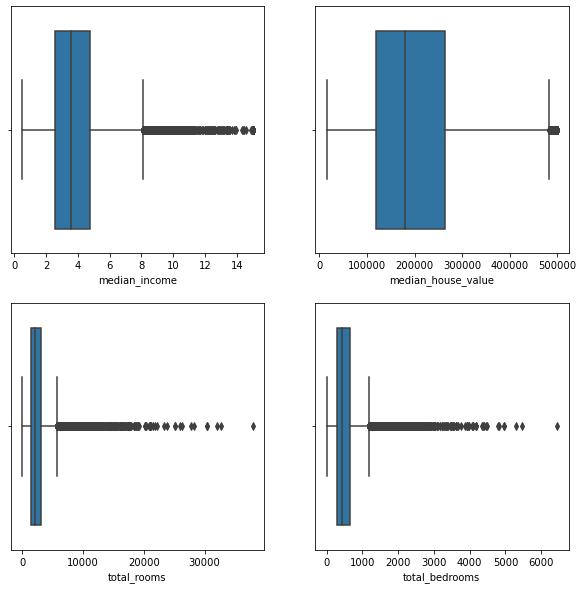

```python
plt.figure(figsize=(10,10))

plt.subplot(2,2,1)
sns.boxplot(x="median_income", data=train)
plt.subplot(2,2,2)
sns.boxplot(x="median_house_value", data=train)

plt.subplot(2,2,3)
sns.boxplot(x="total_rooms", data=train)
plt.subplot(2,2,4)
sns.boxplot(x="total_bedrooms", data=train)
```

```python
## 두 컬럼 선택
temp02 = train.loc[:,  [ "median_income", "median_house_value" ] ]
temp02.head()
```

|  | median_income | median_house_value |
| --- | --- | --- |
| 0 | 1.4936 | 66900.0 |
| 1 | 1.8200 | 80100.0 |
| 2 | 1.6509 | 85700.0 |
| 3 | 3.1917 | 73400.0 |
| 4 | 1.9250 | 65500.0 |

```python
train.columns
```

```
Index(['longitude', 'latitude', 'housing_median_age', 'total_rooms',
       'total_bedrooms', 'population', 'households', 'median_income',
       'median_house_value'],
      dtype='object')
```

```python
## 두 컬럼 선택 8열, 9열
temp03 = train.iloc[:,  [7, 8] ]
print( temp03.head() )

temp03 = train.iloc[:,  [-2, -1] ]
print( temp03.head() )
```

```
   median_income  median_house_value
0         1.4936             66900.0
1         1.8200             80100.0
2         1.6509             85700.0
3         3.1917             73400.0
4         1.9250             65500.0
   median_income  median_house_value
0         1.4936             66900.0
1         1.8200             80100.0
2         1.6509             85700.0
3         3.1917             73400.0
4         1.9250             65500.0
```

```python
temp04 = train.iloc[:,  [6, 7, 8] ]
print(temp04.head() )
```

```
   households  median_income  median_house_value
0       472.0         1.4936             66900.0
1       463.0         1.8200             80100.0
2       117.0         1.6509             85700.0
3       226.0         3.1917             73400.0
4       262.0         1.9250             65500.0
```

```python
## 그렇다면 일부 열의 부분을 가져올 수 없을까?
## range 와
scope = list(range(6,9,1))   # 6번째부터 8번째까지 범위 지정.
temp = train.iloc[:, scope ] # 6,7,8 열을 가져온다.
print(temp.head() )

temp = train.iloc[:, 6:9:1 ] # 6,7,8 열을 가져온다.
print(temp.head() )
```

```
   households  median_income  median_house_value
0       472.0         1.4936             66900.0
1       463.0         1.8200             80100.0
2       117.0         1.6509             85700.0
3       226.0         3.1917             73400.0
4       262.0         1.9250             65500.0
   households  median_income  median_house_value
0       472.0         1.4936             66900.0
1       463.0         1.8200             80100.0
2       117.0         1.6509             85700.0
3       226.0         3.1917             73400.0
4       262.0         1.9250             65500.0
```

```python
train.head()
```

|  | longitude | latitude | housing_median_age | total_rooms | total_bedrooms | population | households | median_income | median_house_value |
| --- | --- | --- | --- | --- | --- | --- | --- | --- | --- |
| 0 | -114.31 | 34.19 | 15.0 | 5612.0 | 1283.0 | 1015.0 | 472.0 | 1.4936 | 66900.0 |
| 1 | -114.47 | 34.40 | 19.0 | 7650.0 | 1901.0 | 1129.0 | 463.0 | 1.8200 | 80100.0 |
| 2 | -114.56 | 33.69 | 17.0 | 720.0 | 174.0 | 333.0 | 117.0 | 1.6509 | 85700.0 |
| 3 | -114.57 | 33.64 | 14.0 | 1501.0 | 337.0 | 515.0 | 226.0 | 3.1917 | 73400.0 |
| 4 | -114.57 | 33.57 | 20.0 | 1454.0 | 326.0 | 624.0 | 262.0 | 1.9250 | 65500.0 |

```python
train.total_rooms.describe()
```

```
count    17000.000000
mean      2643.664412
std       2179.947071
min          2.000000
25%       1462.000000
50%       2127.000000
75%       3151.250000
max      37937.000000
Name: total_rooms, dtype: float64
```

### 조건을 이용하여 데이터 그룹을 시켜보자.

```python
# 전체 방의 수를 위의 값을 기준으로 네 그룹으로 나눈다.
# A1 : 75~100  3151 ~
# A2 : 50~75   2127 ~ 3151
# A3 : 25~50   1462 ~ 2127
# A4 : 0~25    ~1462

tmp_A1 = train[ train['total_rooms']> 3151]
print(tmp_A1.head())
print(tmp_A1.shape)
```

```
    longitude  latitude  housing_median_age  total_rooms  total_bedrooms  \
0     -114.31     34.19                15.0       5612.0          1283.0
1     -114.47     34.40                19.0       7650.0          1901.0
8     -114.59     33.61                34.0       4789.0          1175.0
10    -114.60     33.62                16.0       3741.0           801.0
38    -115.48     32.68                15.0       3414.0           666.0

    population  households  median_income  median_house_value
0       1015.0       472.0         1.4936             66900.0
1       1129.0       463.0         1.8200             80100.0
8       3134.0      1056.0         2.1782             58400.0
10      2434.0       824.0         2.6797             86500.0
38      2097.0       622.0         2.3319             91200.0
(4250, 9)
```

```python
import numpy as np
```

```python
## 두개의 조건문 np.where를 이용하여 확인
bool_val = np.where( (train['total_rooms']> 1462) & (train['total_rooms'] <= 2127), True, False)
type(bool_val)
print(bool_val)
```

```
[False False False ... False False  True]
```

```python
train[ bool_val ]
```

|  | longitude | latitude | housing_median_age | total_rooms | total_bedrooms | population | households | median_income | median_house_value |
| --- | --- | --- | --- | --- | --- | --- | --- | --- | --- |
| 3 | -114.57 | 33.64 | 14.0 | 1501.0 | 337.0 | 515.0 | 226.0 | 3.1917 | 73400.0 |
| 9 | -114.60 | 34.83 | 46.0 | 1497.0 | 309.0 | 787.0 | 271.0 | 2.1908 | 48100.0 |
| 11 | -114.60 | 33.60 | 21.0 | 1988.0 | 483.0 | 1182.0 | 437.0 | 1.6250 | 62000.0 |
| 16 | -114.65 | 33.60 | 28.0 | 1678.0 | 322.0 | 666.0 | 256.0 | 2.9653 | 94900.0 |
| 20 | -114.68 | 33.49 | 20.0 | 1491.0 | 360.0 | 1135.0 | 303.0 | 1.6395 | 44400.0 |
| ... | ... | ... | ... | ... | ... | ... | ... | ... | ... |
| 16975 | -124.17 | 40.76 | 26.0 | 1776.0 | 361.0 | 992.0 | 380.0 | 2.8056 | 82800.0 |
| 16977 | -124.17 | 40.62 | 32.0 | 1595.0 | 309.0 | 706.0 | 277.0 | 2.8958 | 86400.0 |
| 16978 | -124.18 | 40.79 | 39.0 | 1836.0 | 352.0 | 883.0 | 337.0 | 1.7450 | 70500.0 |
| 16980 | -124.18 | 40.78 | 34.0 | 1592.0 | 364.0 | 950.0 | 317.0 | 2.1607 | 67000.0 |
| 16999 | -124.35 | 40.54 | 52.0 | 1820.0 | 300.0 | 806.0 | 270.0 | 3.0147 | 94600.0 |

4249 rows × 9 columns

```python
bool_val = np.where( (train['total_rooms']> 2127) & (train['total_rooms'] <= 3151), True, False)
print(bool_val.shape)
tmp_A2 = train[ bool_val ]
print(tmp_A2.shape)
```

```
(17000,)
(4247, 9)
```

```python
bool_val = np.where( (train['total_rooms']> 1462) & (train['total_rooms'] <= 2127), True, False)
print(bool_val.shape)
tmp_A3 = train[ bool_val ]
print(tmp_A3.shape)
```

```
(17000,)
(4249, 9)
```

```python
bool_val = np.where( (train['total_rooms']> 1462) , True, False)
print(bool_val.shape)
tmp_A4 = train[ bool_val ]
print(tmp_A4.shape)
```

```
(17000,)
(12746, 9)
```

```python
print(tmp_A1.shape, tmp_A2.shape, tmp_A3.shape, tmp_A4.shape )
```

```
(4250, 9) (4247, 9) (4249, 9) (12746, 9)
```

```python
### 새로운 컬럼 room_level 만들기
# 전체 방의 수를 위의 값을 기준으로 네 그룹으로 나눈다.
# A1 : 75~100  3151 ~
# A2 : 50~75   2127 ~ 3151
# A3 : 25~50   1462 ~ 2127
# A4 : 0~25    ~1462

bool_val = np.where( (train['total_rooms']> 1462) & (train['total_rooms'] <= 2127), True, False)
train.loc[bool_val, "room_level"] = 3
train['room_level'].head()
```

```
0    NaN
1    NaN
2    NaN
3    3.0
4    NaN
Name: room_level, dtype: float64
```

```python
bool_val = np.where( (train['total_rooms']> 2127) & (train['total_rooms'] <= 3151), True, False)
train.loc[bool_val, "room_level"] = 2
train['room_level'].head()
```

```
0    NaN
1    NaN
2    NaN
3    3.0
4    NaN
Name: room_level, dtype: float64
```

```python
### 새로운 컬럼 room_level 만들기
bool_val = np.where( (train['total_rooms']> 3151) , True, False)
train.loc[bool_val, "room_level"] = 1

bool_val = np.where( (train['total_rooms'] <= 1462) , True, False)
train.loc[bool_val, "room_level"] = 4
train['room_level'].head()
```

```
0    1.0
1    1.0
2    4.0
3    3.0
4    4.0
Name: room_level, dtype: float64
```

```python
train.columns
```

```
Index(['longitude', 'latitude', 'housing_median_age', 'total_rooms',
       'total_bedrooms', 'population', 'households', 'median_income',
       'median_house_value', 'room_level'],
      dtype='object')
```

## groupby를 활용한 그룹별 평균

```python
### room_level의 그룹별 나이대 알아보기
print(train.groupby('room_level')['housing_median_age'].mean())
```

```
room_level
1.0    21.170353
2.0    28.872145
3.0    31.580137
4.0    32.731782
Name: housing_median_age, dtype: float64
```

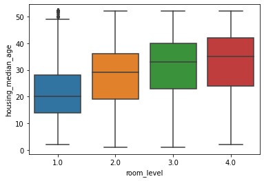

```python
### room_level별 boxplot
### 방이 적으면 적을 수록 나이대가 높다.
### 젊은 층이 많을 수록 지역별 총 방의 수는 많음을 알 수 있다.
sns.boxplot(x="room_level", y="housing_median_age", data=train)
```

### Reference

- https://pandas.pydata.org/pandas-docs/stable/user_guide/10min.html